# officer options

Andrew Ba Tran

May 26, 2016

# Exploring different ways to visualize traffic data for individual police officers.

## Officer: Waterbury–2103

## Waterbury Police | Traffic Stops

### 37.69 percent of drivers stopped by Officer Waterbury–2103 were minorities, compared with Waterbury’s 55.98 percent and state’s 31.04 percent statewide.

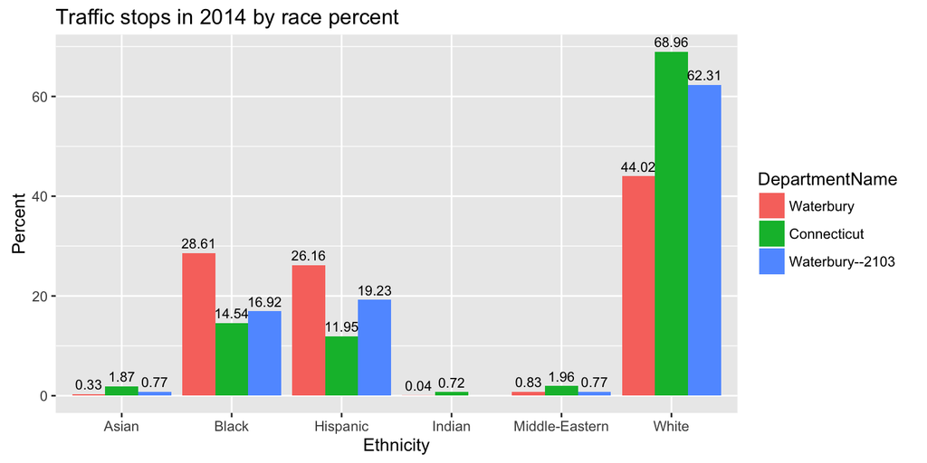

### 55.98 % NON-WHITE

The driving-age population is 55.98 percent minority in Waterbury and 31.04 minority statewide.

## Gender

For officer Waterbury–2103

- **57.69** percent were men
- **42.31** were women

In Waterbury

- **66.78** percent were men
- **33.22** were women

Statewide

- **63.16** percent were men
- **36.84** were women

### The median age for drivers stopped by officer Waterbury–2103 was 35 versus 34 in Waterbury and 36 years old statewide.

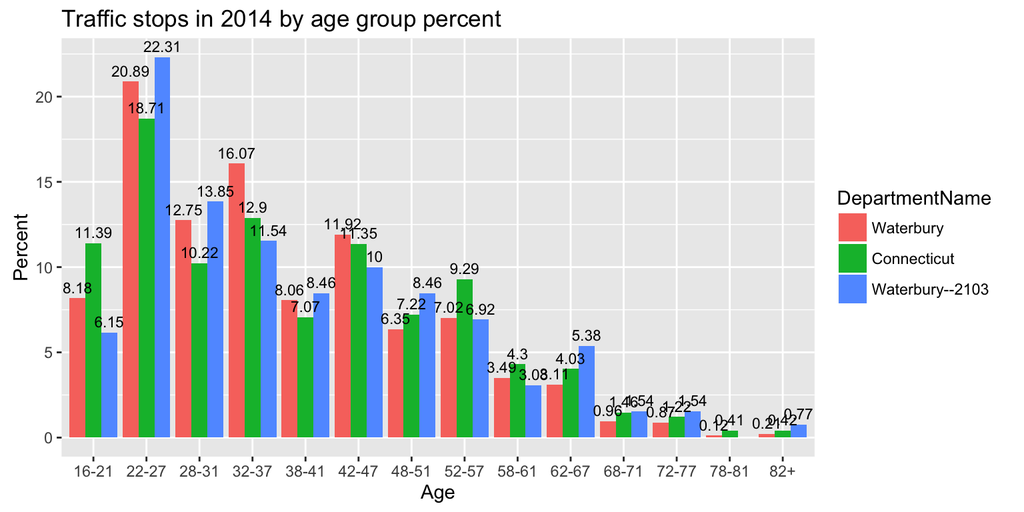

### When

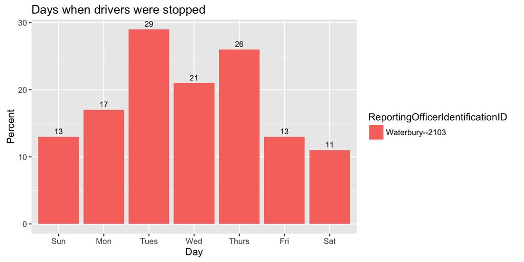

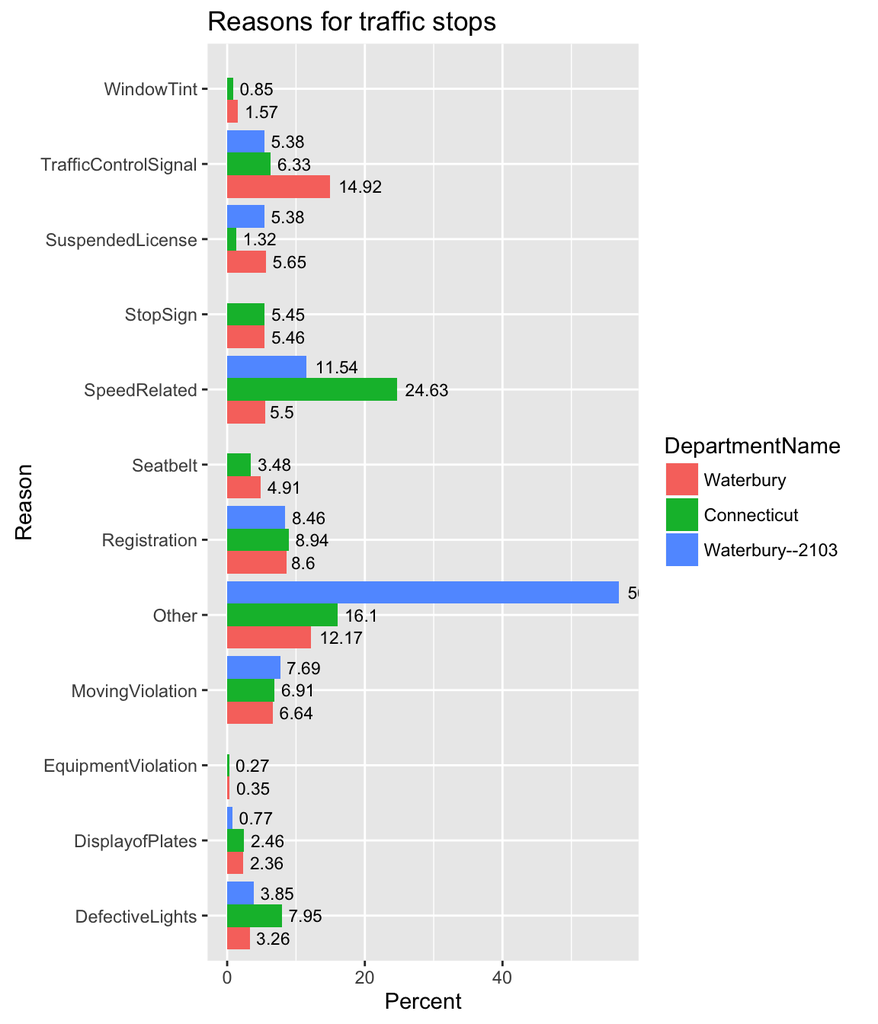

### After traffic stops

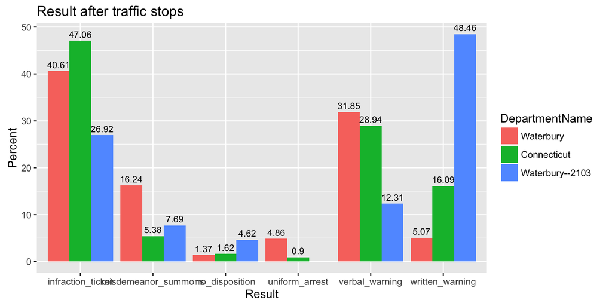

### Searches

This chart shows the percentage of all stops involving searches of cars driven by white or non-white drivers.

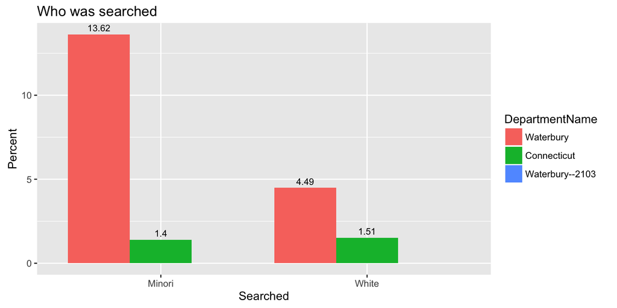

## Residential stops

For officer Waterbury–2103

- **56.15** percent were residents
- **43.85** were non-residents

In Waterbury

- **73.59** percent were residents
- **26.41** were non-residents

## Black drivers: Of those stopped, how many were residents or non-residents?

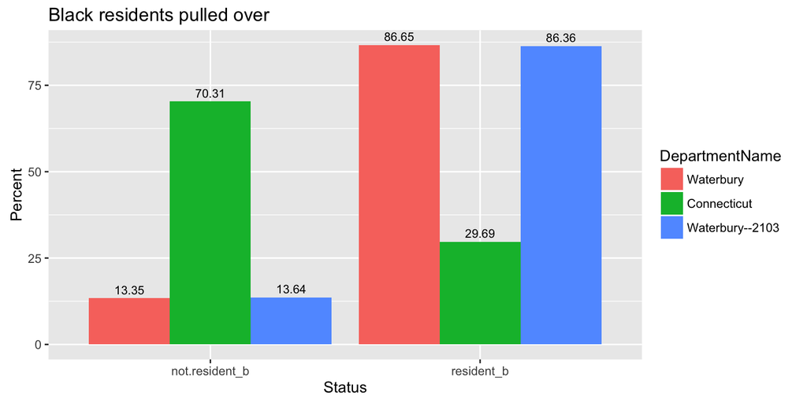

## Hispanic drivers: Of those stopped, how many were residents or non-residents?

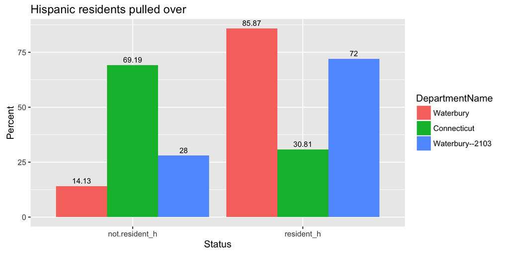

## Non-white drivers: Of those stopped, how many were residents or non-residents?

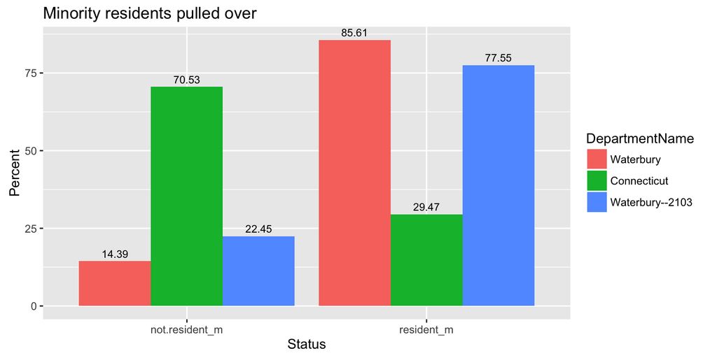

## Type of stops

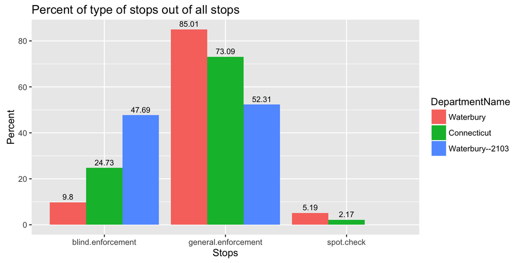

## Spot checks

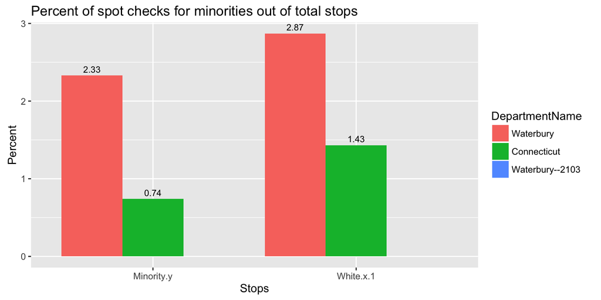

## Blind enforcement

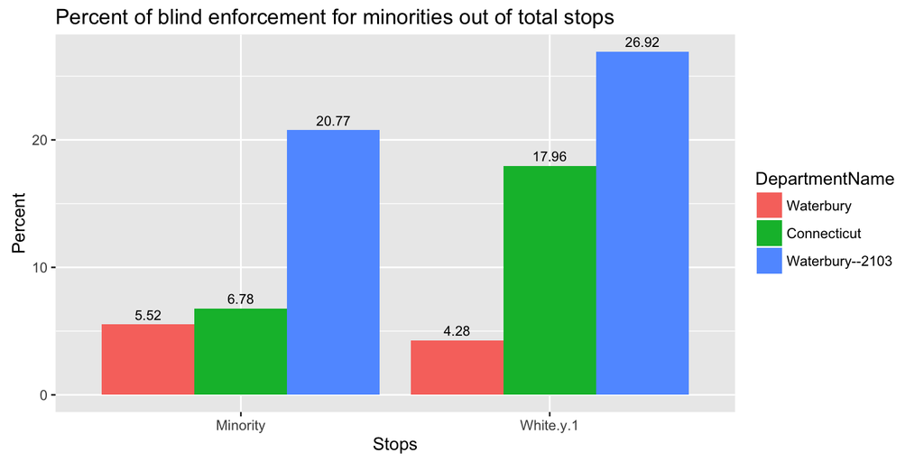

## About Waterbury

- Number of employees in department: **332** (30.32 per 10,000 residents)
- Number of officers: **271** (24.75 per 10,000 residents)
- Number of civilian workers: **61** (5.57 per 10,000 residents)

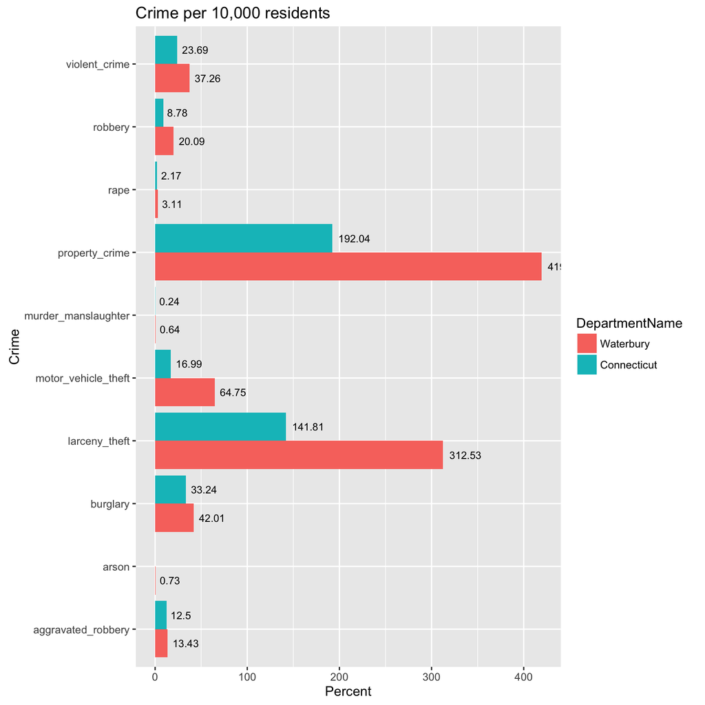